# Titantic Data Investigation

### Q2a - 1：Does the number of spouse really have no effect on the survival outcome?

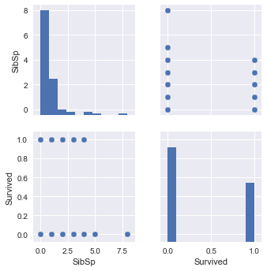

```python
price_pairplot = sns.pairplot(data=pax_list, vars=['SibSp','Survived'])
plt.show()
```

From the above plot we can see that no pax with 5 or more spouse survived.

### Q3: As is in the moive of Titanic, Women were given privilige to board the life boat first, is that ture? Were women on board have higher survival ratio than men?

```python
## Tansform sex col into boolean and calculate the correlation between sex and survival

print ((pax_list['Sex'] == 'male').head())
print (correlation((pax_list['Sex'] == 'male'), pax_list['Survived']))

## The correlation between sex and survival is -0.54, indicates that in the Titanic accident, female (sex=0) had higher chance of survival
## (survival=1) , r = -0.54 ,which indicates that, in the story in the film Titanic, women was given the priority to take the life boat, may be
## true.
```

```
0     True
1    False
2    False
3    False
4     True
Name: Sex, dtype: bool
-0.5433513806577472
```

### Q2b: Given the result of Q2 shows that survival ratio have correlation to class to some extent, so tring to group the pax with different class to gain more understanding the correlation

```python
def clean_data_2(target_pd):
    target_pd['Pclass'] = target_pd['Pclass'].apply(convert_class)
    return target_pd

clean_data_2(pax_list)

mean_survive_ratio_by_class = pax_list.groupby('Pclass', as_index=False)['Survived'].mean()
mean_survive_ratio_by_class_1 = pax_list.groupby('Pclass')['Survived'].mean()
mean_survive_ratio_by_class_2 = pax_list.groupby('Pclass')[['Survived']].mean()
print (mean_survive_ratio_by_class)
print (mean_survive_ratio_by_class_1)
print (mean_survive_ratio_by_class_2)

mean_survive_ratio_by_class_3 = pax_list.groupby(['Pclass', 'Sex'])[['Survived']].mean()
print (mean_survive_ratio_by_class_3)
```

```
  Pclass  Survived
0    1st  0.629630
1    2nd  0.472826
2    3rd  0.242363
Pclass
1st    0.629630
2nd    0.472826
3rd    0.242363
Name: Survived, dtype: float64
        Survived
Pclass
1st     0.629630
2nd     0.472826
3rd     0.242363
               Survived
Pclass Sex
1st    female  0.968085
       male    0.368852
2nd    female  0.921053
       male    0.157407
3rd    female  0.500000
       male    0.135447
```

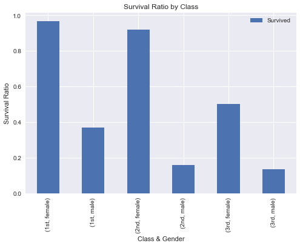

```python
## plt.hist(mean_survive_ratio_by_class)
## ref: https://discussions.udacity.com/t/have-problem-when-using-hist-to-plot-titanic-data/215534/2
mean_survive_ratio_by_class_3.plot(kind="bar", title='Survival Ratio by Class')
plt.xlabel('Class & Gender')
plt.ylabel('Survival Ratio')
plt.show()

## From the bar chart we can see that the average survial ratio in the accident is differ significantly. Pax in more permier class looks
## had a much higher average survival ratio in the accident.
```

From the plot above, both for men and women, passengers in higher class have higher survival ratio.

## Conclusion

#### Limitation of the conlusion:

- Because the data only include 891 out of the 2224 passengers, and the sampling methon is unknown, the observation of the sample may not reflect the situation of Titanic incident precisely. Also, the correlations state below represent the situiation of the sample only, not tested toward the conclusion of causation.

#### Given the available information (Class, Gender, Age etc.) in the data set, Which factor may have more correlation to the survival ratio than others?

- From the correlation calculation, survival ratio seems not related to the age of passengers (r = -0.07), the number of spouse on board (r= -0.03), the number of parent and children on board (r = 0.08). However, passengers with 5 or more spouse on board did not make themself survive.
- From the data set, the pax in higher class had greater chance of survival, in the Titanic accident (r = -0.34), both for men or women. The survival ratio for 1st, 2nd and 3rd class sampled passengers were 0.629630, 0.472826, 0.242363 respectively.
- The higher class may have more easy access to both the life boat and exit passage, which may help the passengers in higher cabin to survive.

#### As is in the moive of Titanic, Women were given privilige to board the life boat first, is that ture? Were women on board have higher survival ratio than men?

- True. Women's survival ratio was significantly higher than men, for all the classes. The R between sex and survial was -0.54.